# WNBA Eda Project - Belle Schmidt

2024-06-06

# Overarching Question 1 - How Does The League Overall Perform in Close Home Compared To Close Away Games?

## Close Game Wins vs. Losses Across Whole WNBA

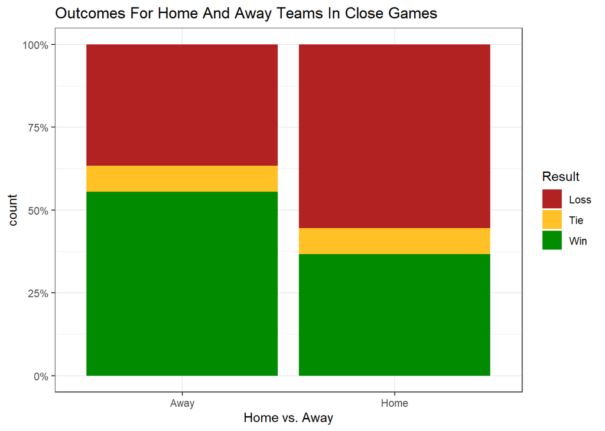

```r
# Home vs. Away Outcomes
league_win_vs_losses <- ggplot(win_losses, aes(x = home_or_away_result, fill = win_or_loss)) +
  geom_bar(position = position_fill()) +
  scale_y_continuous(labels = scales::percent_format(accuracy = 1)) +
  scale_fill_manual(values = c("firebrick", "goldenrod1", "green4")) +
  labs(title = "Outcomes For Home And Away Teams In Close Games",
       x = "Home vs. Away",
       fill = "Result")


league_win_vs_losses
```

Plot Description: From this plot we can determine that in a close WNBA game, the away team is more likely to win than the home team.

## Outcome Type Related To Home and Away Across The League

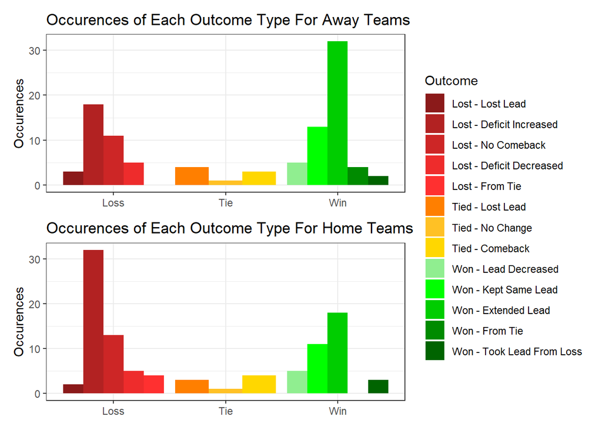

```r
# Home Outcome Types Occured Across Leagues In Close Games

home_outcomes <- ggplot(possible_outcomes, aes(x = Win_Loss, y = num_times_home, fill = outcome)) +
  geom_bar(stat = "identity", position = "dodge") +
  labs(title = "Occurences of Each Outcome Type For Home Teams",
       y = "Occurences",
       fill = "Outcome") +
  scale_fill_manual(values = win_loss_color_vector) +
  theme(axis.title.x = element_blank())



# Away Outcome Types Occured Across Leagues In Close Games
away_outcomes <- ggplot(possible_outcomes, aes(x = Win_Loss, y = num_times_away, fill = outcome)) +
  geom_bar(stat = "identity", position = "dodge") +
  labs(title = "Occurences of Each Outcome Type For Away Teams",
       y = "Occurences",
       fill = "Outcome") +
  scale_fill_manual(values = win_loss_color_vector)+
  theme(axis.title.x = element_blank())

# Combined Graph of Away vs Home Team Outcomes; Point Out Away Teams Win More In Close Games
library(patchwork)

away_outcomes + home_outcomes +
  plot_layout(guides = "collect", nrow = 2) +
  labs("Occurences Of Each Outcome Type For Both Home and Away Teams In Close Games")
```

**Plot Description:** From the *Occurrences Of Each Outcome Type For Both Home and Away Teams* graph, we can learn that in close games, the team that won (regardless of if they were home or away) most likely extended their lead between the time of the first shot in the last 30 seconds and the end of the game. This corresponds with the idea that the team that lost, most likely lost with a higher deficit than what they were down after the first shot in the last 30 seconds of the game. For games that ended the 4th quarter with a tie, however, it is most likely that a team had the lead after the first shot in the last 30 seconds but then the other team tied it up. There were slightly more occurrences of the away team having the lead and losing it, however, it is hard to predict if home or away is a predictor because there were only a handful of occurrences.

## League Shooting Percentage Home vs. Away

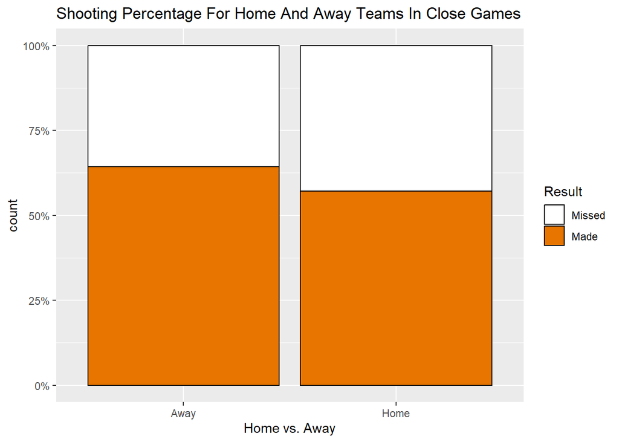

```r
  ggplot(all_close_game_shots, aes(x = Shooting_Team_Home_Away)) +
  geom_bar(aes(fill = made_shot), color = "black", position = "fill") +
  scale_y_continuous(labels = scales::percent_format(accuracy = 1)) +
  scale_fill_manual(values = c("white", "#E77500")) +
  labs(title = "Shooting Percentage For Home And Away Teams In Close Games",
       x = "Home vs. Away",
       fill = "Result") +
  theme_gray()
```

# Overarching Question 2 - How Do Each Of The Teams Perform In Close Home Compared To Close Away Games?

## Number of Close Home And Away Games (6 points or less with 30 seconds left) Per Team - Need ShinyApp

[figure not shown]

```r
win_losses2 <- close_games_observing |>
  pivot_longer(home_team_name:away_team_name,
               values_to = "teams",
               names_to = "home_or_away_team") |>
  mutate(home_or_away_team = ifelse(home_or_away_team == "home_team_name", "Home", "Away"))

win_losses2 |>
  filter(teams == "Atlanta Dream")|>
ggplot(aes(x = fct_rev(fct_infreq(teams)), fill = home_or_away_team)) +
  geom_bar(color = "black") +
  coord_flip() +
  scale_fill_manual(values = c("white", "#E77500")) +
  labs(title = "Number of Close Home And Away Games Per Team",
       y = "Number of Close Games",
       x = "WNBA Team",
       subtitle = "Close games is defined as a score differential of 6 or less in the last 30 seconds",
       fill = "Home or Away") +
  theme_gray()
```

## Each Team’s Number of Wins And Losses In Close Home vs. Away Games - Need To Use Same Shiny App As Above

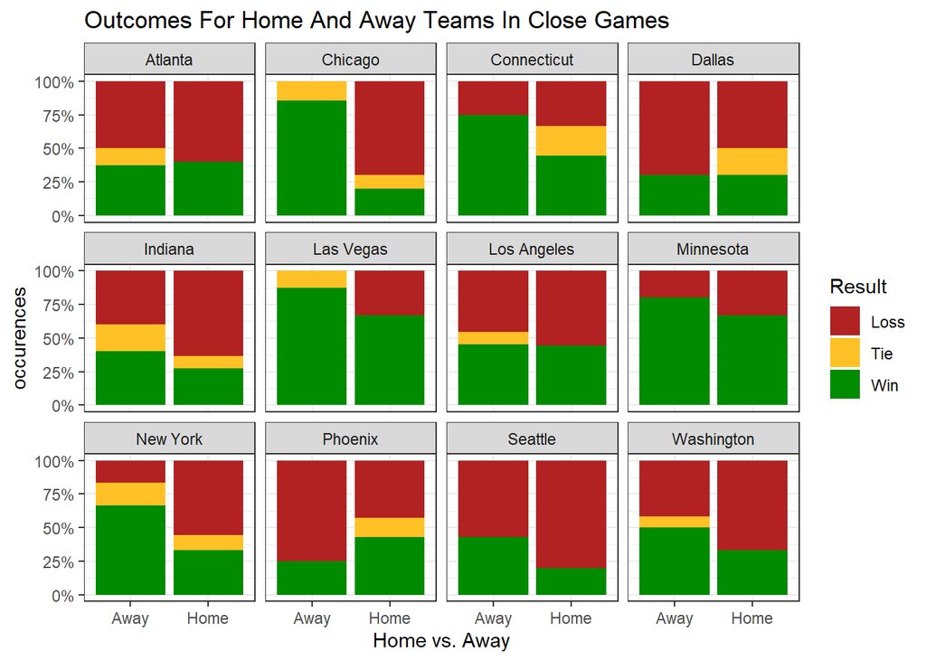

```r
# Home vs. Away Outcomes
team_win_vs_losses <- win_loss_per_team |>
  ggplot(aes(x = home_or_away, y = occurences, fill = result)) +
  geom_bar(position = position_fill(), stat = "identity") +
  scale_y_continuous(labels = scales::percent_format(accuracy = 1)) +
  scale_fill_manual(values = c("firebrick", "goldenrod1", "green4")) +
  labs(title = "Outcomes For Home And Away Teams In Close Games",
       x = "Home vs. Away",
       fill = "Result") +
  facet_wrap(~team)


team_win_vs_losses
```

## Outcome Types For Each Team When Home vs. Away

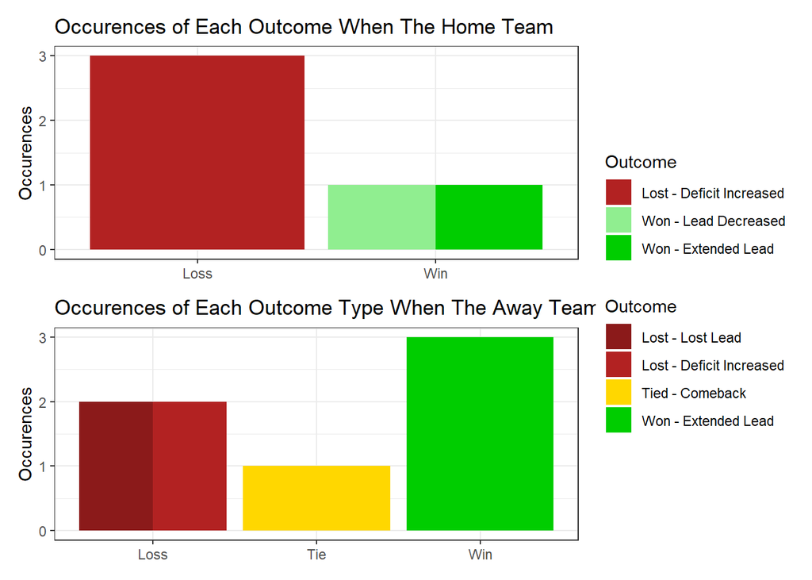

```r
# Home Outcome Types Occurred Across Leagues In Close Games - Need Shiny App
Team_home_outcomes <- home_game_results |>
  ungroup() |>
  filter(home_team_name == "Atlanta")|>
  ggplot(aes(x = Home_Result, y = num_times_home_per_team, fill = outcome)) +
  geom_bar(stat = "identity", position = "dodge") +
  labs(title = "Occurences of Each Outcome When The Home Team",
       y = "Occurences",
       fill = "Outcome") +
  scale_fill_manual(values = win_loss_color_vector) +
  theme(axis.title.x = element_blank())

# Team_home_outcomes


# Away Outcome Types Occurred Across Leagues In Close Games - Need Shiny App

Team_away_outcomes <- away_game_results |>
  ungroup() |>
  filter(away_team_name == "Atlanta")|>
  ggplot(aes(x = Away_Result, y = times_occured_away_per_team, fill = outcome)) +
  geom_bar(stat = "identity", position = "dodge") +
  labs(title = "Occurences of Each Outcome Type When The Away Team",
       y = "Occurences",
       fill = "Outcome") +
  scale_fill_manual(values = win_loss_color_vector) +
  theme(axis.title.x = element_blank())

# Combined Outcomes For Teams When They Are Home And Away

library(patchwork)

Team_home_outcomes + Team_away_outcomes +
  plot_layout(guides = "collect", nrow = 2)
```

## Graph For Number of Shots Taken By Each of The WNBA Teams In Final 30 Seconds of Close Games - The Filter is to be changed by shiny app

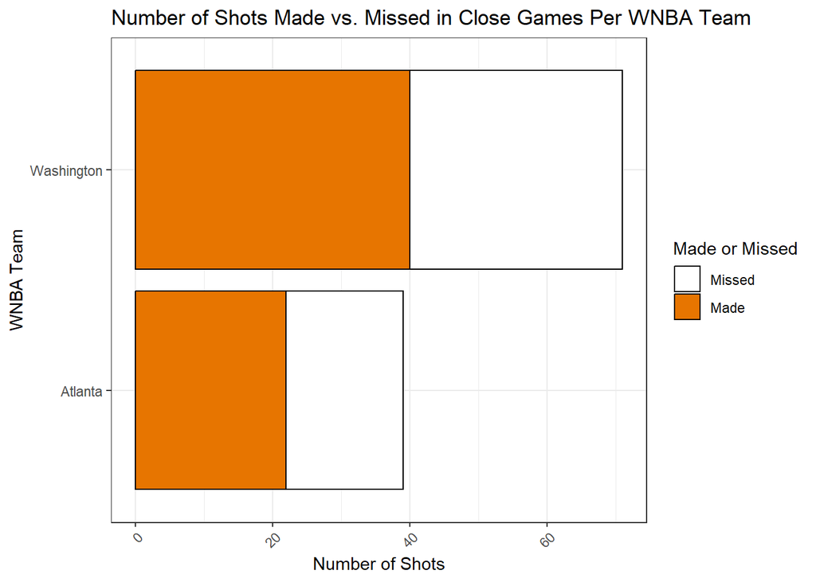

```r
all_close_game_shots |>
  filter(shooting_team == "Atlanta" | shooting_team == "Washington") |>
  ggplot(aes(x = fct_rev(fct_infreq(shooting_team)), fill = made_shot))  +
  geom_bar(color = "black") +
  theme(axis.text.x=element_text(angle=45, hjust=0.9)) +
  scale_fill_manual(values = c("white", "#E77500")) +
  coord_flip() +
  labs(title = "Number of Shots Made vs. Missed in Close Games Per WNBA Team",
       x = "WNBA Team",
       y = "Number of Shots",
       fill = "Made or Missed"
       )
```

## Each Team’s Shooting Percentage (Home and Away) - The Filter Is Changed By Same Shiny App As Above

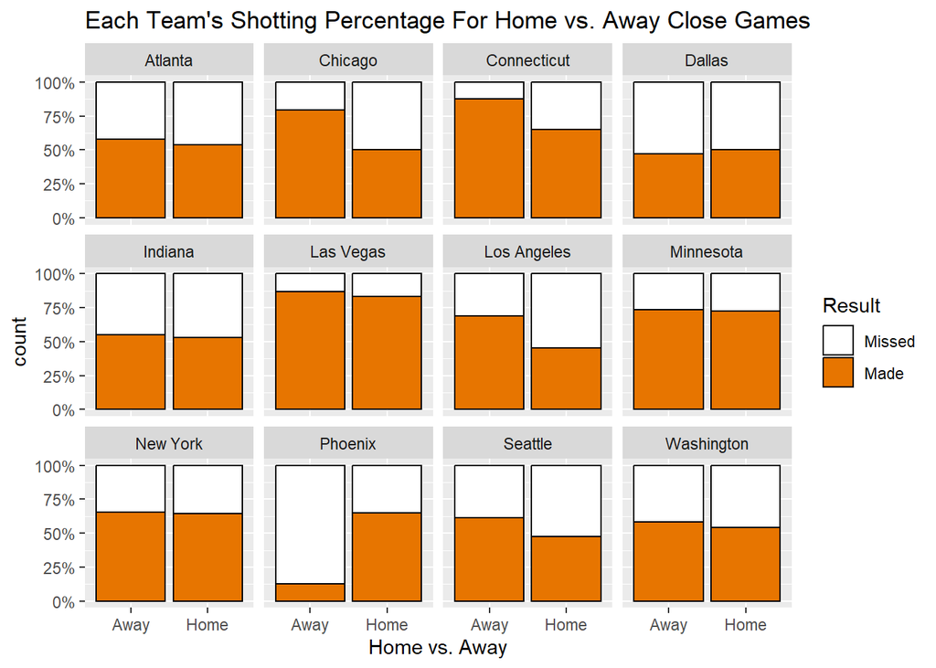

```r
all_close_game_shots |>
ggplot(aes(x = Shooting_Team_Home_Away)) +
  geom_bar(aes(fill = made_shot), color = "black", position = "fill") +
  scale_y_continuous(labels = scales::percent_format(accuracy = 1)) +
  scale_fill_manual(values = c("white", "#E77500")) +
  labs(title = "Each Team's Shotting Percentage For Home vs. Away Close Games",
       x = "Home vs. Away",
       fill = "Result") +
  theme_gray() +
  facet_wrap(~shooting_team)
```

# Overarching Question - How does time left in the game impact each team’s performance?

- Make Graph For Shooting Percentage in the last 30 seconds per team
- Make Graph For Overall Shooting Percentage per team
- Make Graph For Final Possession Shooting Percentage per team
- Make Graph For Each Quarter’s shooting percentage per team
- Make Graph For Start and end of half shooting percentage per team

## Graph For Shooting Percentage of WNBA Teams In Final 30 Seconds of Close Games

[figure not shown]

```r
shooting_percentage |>
  ggplot(aes(x = reorder(shooting_team, shot_percentage), y = shot_percentage, fill = shooting_team)) +
  geom_bar(stat = "identity") +
   scale_fill_manual(values = c("#C8102E", "#418FDE", "#643335", "#C4D600", "#FFCD00", "#000000", "#702F8A", "#236192", "#003DA5","#CB6015","#2C5234", "#0C2340")) +
  theme_bw() +
  theme(axis.text.x=element_text(angle=45, hjust=0.9)) +
  coord_flip()
```

# Final Possession

## Games With Close Scores (3 points or less) Down To The Final Possession

```r
final_possession <- wnba_shots |>
  group_by(game_id) |>
  slice_max(game_play_number) |>
  filter(score_differential %in% c(-3, -2, -1, 0, 1, 2, 3))

final_possession
```

```
## # A tibble: 31 × 21
## # Groups:   game_id [31]
##      game_id game_play_number game_type desc      shot_type made_shot shot_value
##        <dbl>            <dbl>     <dbl> <chr>     <chr>     <chr>          <dbl>
##  1 401507143              388         2 Dana Eva… Driving … Made               2
##  2 401507147              416         2 Rhyne Ho… Pullup J… Missed             0
##  3 401507151              394         2 Lexie Hu… Jump Shot Missed             0
##  4 401507155              416         2 Satou Sa… Jump Shot Made               3
##  5 401507157              351         2 Marina M… Turnarou… Missed             0
##  6 401507159              380         2 Ariel At… Jump Shot Missed             0
##  7 401507166              387         2 Ezi Magb… Reverse … Missed             0
##  8 401507172              369         2 Erica Wh… Free Thr… Missed             0
##  9 401507178              372         2 Erica Wh… Step Bac… Missed             0
## 10 401507186              353         2 Alanna S… Jump Shot Missed             0
## # ℹ 21 more rows
## # ℹ 14 more variables: coordinate_x <dbl>, coordinate_y <dbl>,
## #   shooting_team <chr>, home_team_name <chr>, away_team_name <chr>,
## #   home_score <dbl>, away_score <dbl>, qtr <dbl>,
## #   quarter_seconds_remaining <dbl>, game_seconds_remaining <dbl>,
## #   shooting_player <chr>, score_differential <dbl>, free_throw <dbl>,
## #   Shooting_Team_Home_Away <chr>
```

## Number of Times Home Team In Close Game

```r
home_team_in_close_games <- final_possession |>
  group_by(game_id) |>
  slice_head() |>
  group_by(home_team_name) |>
  summarise(num_times_home = n()) |>
  rename(team_name = home_team_name)

home_team_in_close_games
```

```
## # A tibble: 11 × 2
##    team_name   num_times_home
##    <chr>                <int>
##  1 Atlanta                  1
##  2 Chicago                  3
##  3 Connecticut              2
##  4 Dallas                   3
##  5 Indiana                  5
##  6 Los Angeles              3
##  7 Minnesota                2
##  8 New York                 4
##  9 Phoenix                  1
## 10 Seattle                  4
## 11 Washington               3
```

## Number of Times Away Team In Close Game

```r
away_team_in_close_games <- final_possession |>
  group_by(game_id) |>
  slice_head() |>
  group_by(away_team_name) |>
  summarise(num_times_away = n()) |>
  rename(team_name = away_team_name)

away_team_in_close_games
```

```
## # A tibble: 10 × 2
##    team_name   num_times_away
##    <chr>                <int>
##  1 Atlanta                  2
##  2 Chicago                  2
##  3 Dallas                   4
##  4 Indiana                  5
##  5 Las Vegas                3
##  6 Los Angeles              4
##  7 Minnesota                2
##  8 New York                 3
##  9 Phoenix                  2
## 10 Washington               4
```

```r
close_game_appereances <- full_join(away_team_in_close_games, home_team_in_close_games)
close_game_appereances[is.na(close_game_appereances)] <- 0

close_game_appearances <- close_game_appereances |>
  mutate(num_close_games = num_times_away + num_times_home)

close_game_appearances
```

```
## # A tibble: 12 × 4
##    team_name   num_times_away num_times_home num_close_games
##    <chr>                <int>          <int>           <int>
##  1 Atlanta                  2              1               3
##  2 Chicago                  2              3               5
##  3 Dallas                   4              3               7
##  4 Indiana                  5              5              10
##  5 Las Vegas                3              0               3
##  6 Los Angeles              4              3               7
##  7 Minnesota                2              2               4
##  8 New York                 3              4               7
##  9 Phoenix                  2              1               3
## 10 Washington               4              3               7
## 11 Connecticut              0              2               2
## 12 Seattle                  0              4               4
```

## Number of Games That Came Down To Final Possession Per Team

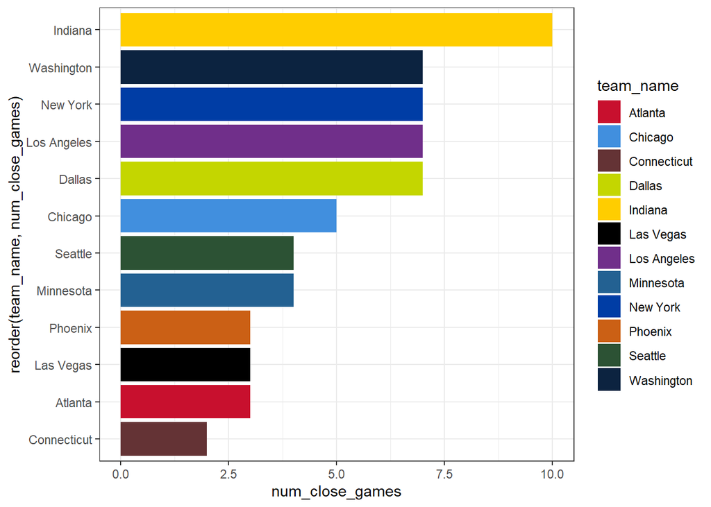

```r
ggplot(close_game_appearances, aes(x = reorder(team_name, num_close_games), y = num_close_games, fill = team_name)) +
  geom_bar(stat = "identity") +
  scale_fill_manual(values = c("#C8102E", "#418FDE", "#643335", "#C4D600", "#FFCD00", "#000000", "#702F8A", "#236192", "#003DA5","#CB6015","#2C5234", "#0C2340")) +
  coord_flip()
```

## Number of Home vs. Away Games That Came Down To Final Possession Per Team

```r
close_game_appearances2 <- close_game_appearances |>
  select(!num_close_games)

library(reshape2)
df_long <- melt(close_game_appearances2)
df_long
```

```
##      team_name       variable value
## 1      Atlanta num_times_away     2
## 2      Chicago num_times_away     2
## 3       Dallas num_times_away     4
## 4      Indiana num_times_away     5
## 5    Las Vegas num_times_away     3
## 6  Los Angeles num_times_away     4
## 7    Minnesota num_times_away     2
## 8     New York num_times_away     3
## 9      Phoenix num_times_away     2
## 10  Washington num_times_away     4
## 11 Connecticut num_times_away     0
## 12     Seattle num_times_away     0
## 13     Atlanta num_times_home     1
## 14     Chicago num_times_home     3
## 15      Dallas num_times_home     3
## 16     Indiana num_times_home     5
## 17   Las Vegas num_times_home     0
## 18 Los Angeles num_times_home     3
## 19   Minnesota num_times_home     2
## 20    New York num_times_home     4
## 21     Phoenix num_times_home     1
## 22  Washington num_times_home     3
## 23 Connecticut num_times_home     2
## 24     Seattle num_times_home     4
```

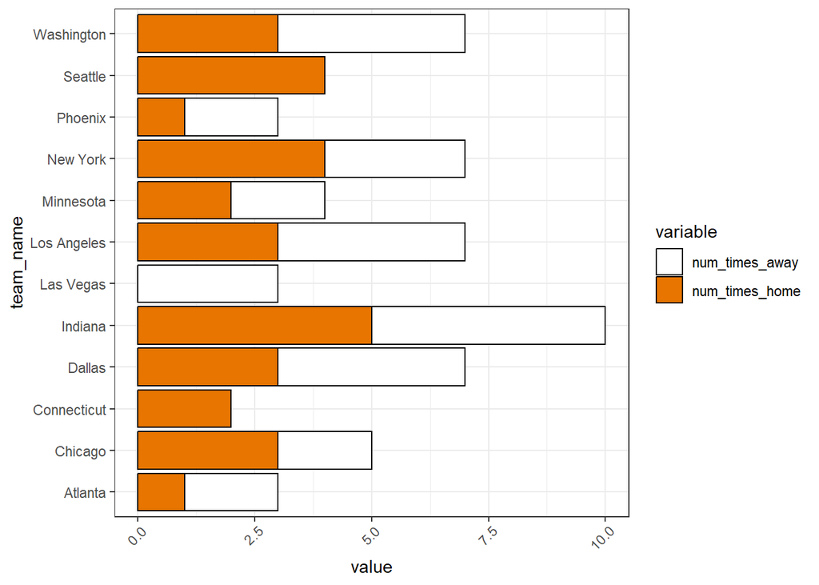

```r
# To Match Previous Styles
ggplot(df_long, aes(x = team_name, y = value, fill = variable)) +
  geom_bar(stat = "identity", position = "stack", color = "black") +
  theme(axis.text.x = element_text(angle = 45, hjust = 0.9)) +
  scale_fill_manual(values = c("white", "#E77500")) +
  coord_flip()
```

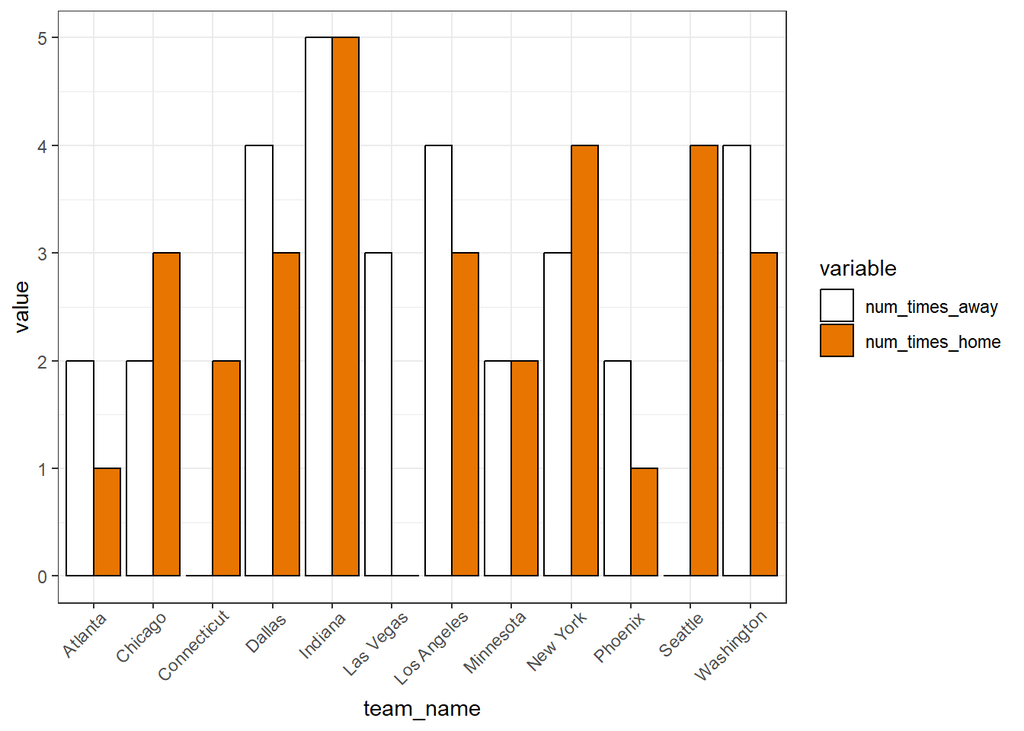

```r
# New Style
ggplot(df_long, aes(x = team_name, y = value, fill = variable)) +
  geom_bar(stat = "identity", position = "dodge", color = "black") +
  theme(axis.text.x = element_text(angle = 45, hjust = 0.9)) +
  scale_fill_manual(values = c("white", "#E77500"))
```

## Teams Who Shot Best In Close Games That Came Down To The Final Possession

```r
final_shots_made_data <- final_possession |>
  mutate(made_shot = if_else(made_shot == "TRUE", 1, 0)) |>
  filter(made_shot == 1) |>
  group_by(shooting_team) |>
  summarise(shots_made = n())

final_shots_taken_data <- final_possession |>
  group_by(shooting_team) |>
  summarise(shots_taken = n())

temp_data_2 <- left_join(final_shots_taken_data, final_shots_made_data)
temp_data_2[is.na(temp_data_2)] <- 0

final_shooting_percentage <- temp_data_2 |>
  mutate(shot_percentage = round(shots_made / shots_taken, 3))

final_shooting_percentage
```

[output not shown]

## Number of Shots That Came Down To Final Possession Per Team (Does Not Include Teams With 0)

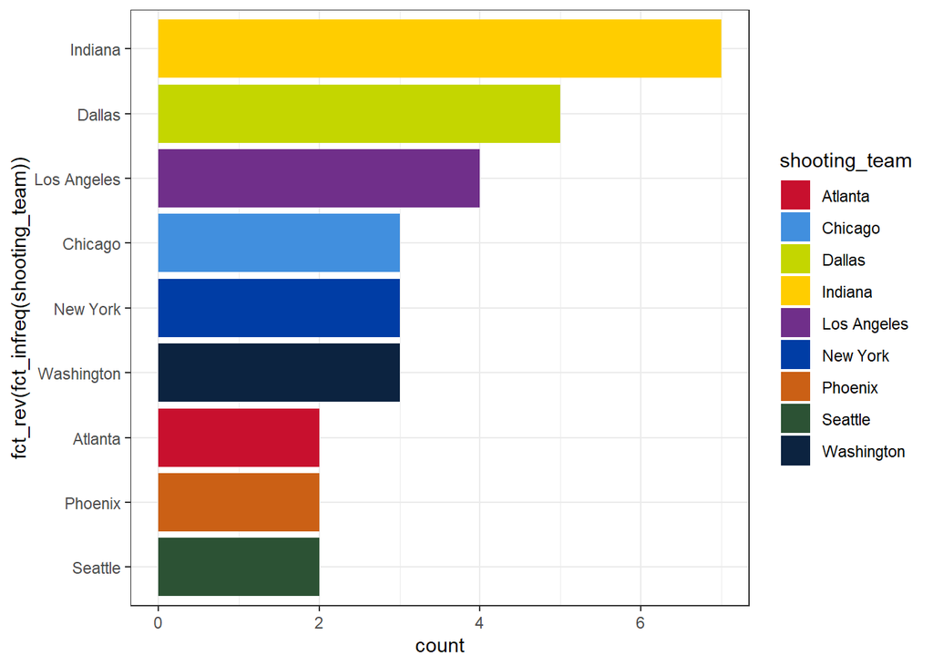

```r
ggplot(final_possession, aes(x = fct_rev(fct_infreq(shooting_team)), fill = shooting_team)) +
  geom_bar() +
  coord_flip() +
  scale_fill_manual(values = c("#C8102E", "#418FDE", "#C4D600", "#FFCD00", "#702F8A",  "#003DA5","#CB6015", "#2C5234", "#0C2340"  ))
```

```r
  # scale_color_manual(values = c("#418FDE", "#FFCD00", "#0C2340", "#041E42", "#FFC72C", "#FF671F", "#201747", "#FBE122", "#C8102E"))
```